# Elevation profile of the Netherlands

Jos Schakenraad[^1]

First published on 2024-04-06 (updated 2024-04-06)

It won’t surprise anyone that the word “elevation” has a little different meaning in this mainly flat and small country than elsewhere. Climbing in the Netherlands - the name of this country literally means low country - is actually a ‘contradictio in terminis’, a contradiction in terms. Nevertheless, there are a number of irregularities in the landscape, apart from dikes and viaducts. The southernmost part of the Netherlands, South Limburg, has been lifted by tectonics, creating a plateau landscape in which a large number of valleys have been carved out by water erosion. Furthermore, the penultimate ice age - the Saale glacial stage - has left its mark on the landscape, especially in the middle of the country. On top of the Vaalserberg you will find the highest point in the Netherlands, at 323 meters above sea level.

# 1. Elevation profile of the Netherlands in 2D

Here’s an R script to get a beautiful 2D map.[^2]

```r
version[['version.string']]
```

```
## [1] "R version 4.3.2 (2023-10-31 ucrt)"
```

```r
library(elevatr)
library(sf)
library(raster)
library(tidyverse)


# Currently, there are two functions in this elevatr package which help users access elevation web services,
# namely, get_elev_point() and get_elev_raster().

# The get_elev_point() function gets the point elevations using the USGS Elevation Point Query Services
# (for United states only) and AWS Terrain Tiles (for all global elevation data).

# Input: This function accepts a data frame of longitude and latitude values (x and y),
# a SpatialPoints/SpatialPointsDataFrame, or a simple feature object (sf). It has a source argument src
# which indicates which API to use, either "eqps" or "aws".
# Output: produces either a SpatialPointsDataFrame or Simple Feature object, depending on the class of input locations.
# The get_elev_point() function can be used as follows:


# The get_elev_raster() function helps users get elevation data as a raster from the AWS Open Data Terrain Tiles.
# The source data are global and also contain the estimations for depth for oceans.

# Input: This takes in a data frame of longitude and latitude values (x and y) or any sp or raster object.
# It has a z argument to determine the zoom or resolution of the raster (1 to 14).
# It also has a clip argument to determine clipping of returned DEM. Options are "tile"
# which is the default value and returns the full tiles, "bbox" which returns the DEM clipped to the bounding box
# of the original locations, or "locations" if the spatial data in the input locations should be used to clip the DEM.

# Output: Returns a raster object of the elevation tiles that cover the bounding box of the input spatial data.

# Now we can use the get_elev_raster() function to obtain the elevation data of the Netherlands.

# Get the province borders, first.

map_provinces_2023 <- st_read("https://service.pdok.nl/cbs/gebiedsindelingen/2023/wfs/v1_0?request=GetFeature&service=WFS&version=2.0.0&typeName=cbsgebiedsindelingen:provincie_gegeneraliseerd&outputFormat=json")
class(map_provinces_2023)
```

```
## [1] "sf"         "data.frame"
```

```r
head(map_provinces_2023)
```

```
## Simple feature collection with 6 features and 5 fields
## Geometry type: MULTIPOLYGON
## Dimension:     XY
## Bounding box:  xmin: 118774.2 ymin: 416104 xmax: 278026.1 ymax: 619231.6
## Projected CRS: Amersfoort / RD New
##   statcode jrstatcode   statnaam   rubriek id                       geometry
## 1     PV20   2023PV20  Groningen provincie  1 MULTIPOLYGON (((276667.5 58...
## 2     PV21   2023PV21    Fryslân provincie  2 MULTIPOLYGON (((154047.9 56...
## 3     PV22   2023PV22    Drenthe provincie  3 MULTIPOLYGON (((228989.6 57...
## 4     PV23   2023PV23 Overijssel provincie  4 MULTIPOLYGON (((182721.3 51...
## 5     PV24   2023PV24  Flevoland provincie  5 MULTIPOLYGON (((187328.4 50...
## 6     PV25   2023PV25 Gelderland provincie  6 MULTIPOLYGON (((169902.6 48...
```

```r
basic_map <- map_provinces_2023 %>%
  ggplot() +
  geom_sf(aes()) +
  labs(title="Provincies in Nederland") +
  geom_sf_text(aes(label = statnaam)) +
  coord_sf() +
  theme(axis.title.x=element_blank(),axis.title.y=element_blank())

#basic_map

elevation_data <- elevatr::get_elev_raster(locations = map_provinces_2023, z = 9, clip = "locations")

elevation_data <- as.data.frame(elevation_data, xy = TRUE)

colnames(elevation_data)[3] <- "elevation"

# remove rows of data frame with one or more NA's, using complete.cases
elevation_data <- elevation_data[complete.cases(elevation_data), ] %>%
  mutate(elevation = if_else(elevation < -10, -8, elevation)) %>%
  mutate(break_elevation = cut(elevation, breaks = c(-999, -5, -1, 0, 5, 15, 25, 50, 100, 200, 300, 999),
                                                          labels = c("< -4", "-4 - -1", "0", "1-5", "6-15", "16-25", "26-50", "51-100", "101-200", "201-300", "> 300")))

class(elevation_data)
```

```
## [1] "data.frame"
```

```r
head(elevation_data)
```

```
##             x      y elevation break_elevation
## 2280 227934.5 619219        -4         -4 - -1
## 2281 228028.5 619219        -4         -4 - -1
## 2282 228122.6 619219        -4         -4 - -1
## 2283 228216.6 619219        -4         -4 - -1
## 2284 228310.7 619219        -4         -4 - -1
## 2285 228404.7 619219        -4         -4 - -1
```

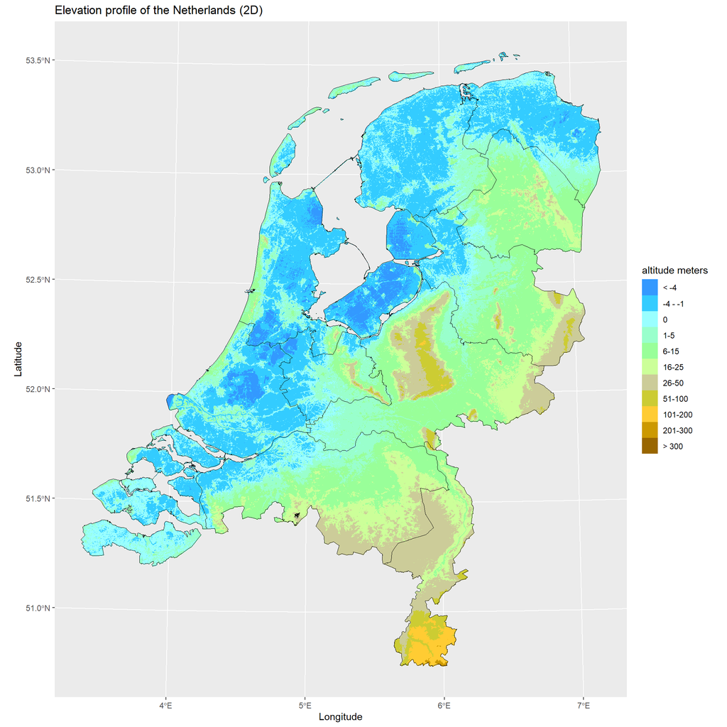

```r
ggplot() +
  geom_raster(data = elevation_data, aes(x = x, y = y, fill = break_elevation)) +
  geom_sf(data = map_provinces_2023, color = "black", fill = NA) +
  coord_sf() +
  scale_fill_manual("altitude meters", values = c("#3399FF","#33CCFF","#99FFFF","#99FFCC","#99FF99","#CCFF99","#CCCC99","#CCCC33","#FFCC33","#CC9900","#996600"), na.value = "grey80")  +
  labs(title = "Elevation profile of the Netherlands (2D)", x = "Longitude", y = "Latitude")
```

# 2. Elevation profile of the Netherlands in 3D

However, for me the most beautiful elevation profile found on the internet is the following 3D map:

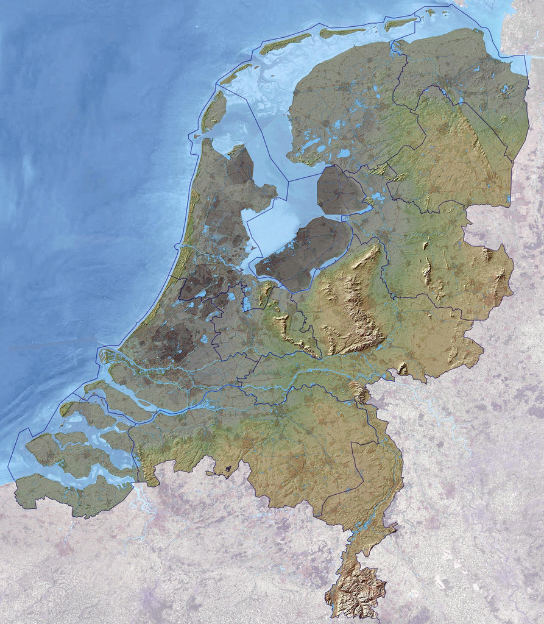

Elevation profile of the Netherlands (3D)

Unfortunately I have not yet managed to program a 3D map in R. To be continued.

[^1]: Geographer, data-analist and cyclist
[^2]: Note on elevatr v0.99.0: Version 0.99.0 of ‘elevatr’ uses ‘sf’ and ‘terra’. Use of the ‘sp’, ‘raster’, and underlying ‘rgdal’ packages by ‘elevatr’ is being deprecated; however, get_elev_raster continues to return a RasterLayer. This will be dropped in future versions, so please plan accordingly.